# Water_yield_FP

Bar Avni

12/7/2016

### Inputs:

The code uses a daily precipitation (mm), temperature (C deg), and discharge (m^3/s) for the years 2011-2015 for Willow creek Pass in the Rocky mountains National Park in Colorado (lat 40.35 log -106.06, figure 1). For calibration, the code make use of stream flow dataset which hase taken from two stations: Willow creek reservoir (drainage area of 347.1 km2 (lat 40.15 log -105.94)) which locates south to the divide and North platte (drainage area of 7355.6 km2 (lat 40.94 log -106.94)) which locates north to the divide. The dataset is taken from NRCS - Natural Resources Conservation Service and National Water and Climate Center [link] (www.wcc.nrcs.usda.gov) . LAI values are taken from Pugh and Gordon (2013) and maximal rain interception is taken from Swank (1968).

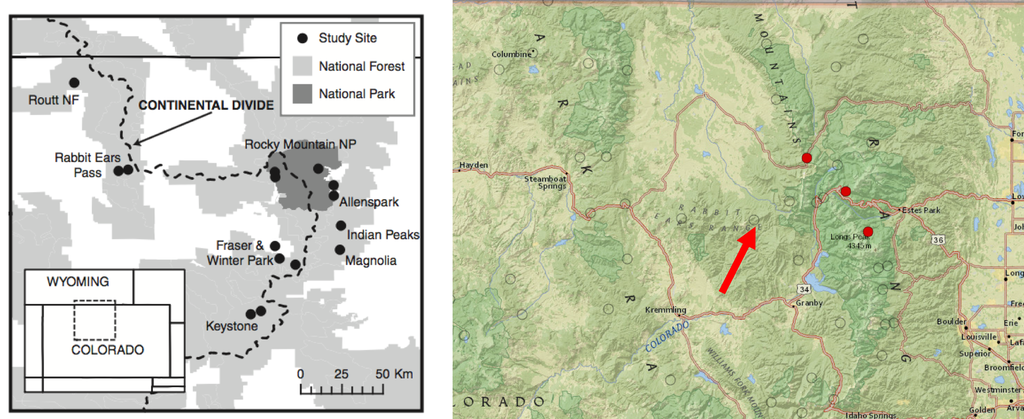

Figure 1. Study area (source: Pugh and Gordon, 2013) and the location of Willow Creek Pass reservoir (source: [link] www.wcc.nrcs.usda.gov)

### Code flowchart

The ecohydrological one dimensional model was built for snowmelt dominated environment. The model compute water yield and contains (1) snow interception model (Hedstrom and Pomeroy, 1998) and rain interception for snowy and rainy days respectively for effective rain/snow calculation.(2) evapotranspiration is calculated using extraterrestrial solar radiation model (Allen et al, 1988) and Hargreaves and Samani (1985) simple evapotranspiration model. The evapotranspiration is calculated as function of LAI (the highest LAI will transmit the maximal solar radiation). (3) Lastly, runoff is calculated taking into account both infiltration and evapotranspiration. Model flowchart is presented in figure 2.

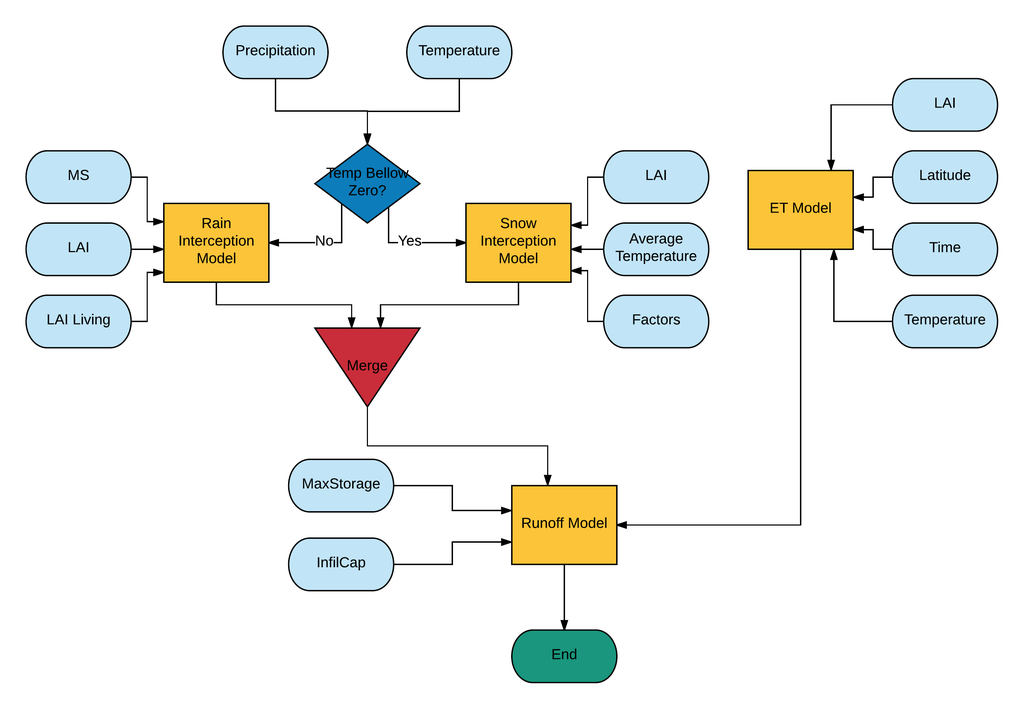

Figure 2. Model flow chart. Inputs are in light blue: Tave is the average temperature (C deg), MS is the maximal rain interception for pine canopy (mm/day), LAI is Leaf Area Index values, LAI living is the LAI values for living and healthy lodgepole pine forest, Temperature refer to mean, maximum and minimum temperature in Celsius degree, time is the exact date, latitude is the latitude of the research area, MaxStorage is the storage capacity of the soil (mm) and InfilCap is the infiltration capacity of the soil (mm/day).

```r
# Set rain data

# Convert the accumulated precipitation to decreet amount (mm).
P = diff(metdata_REP$PA)
P[P < 0] = 0
P = c(0, P)

# Define the snow vs rain seasons
preType = metdata_REP$TMAve < 0
preType = preType*1

# Add the precipitation depth to the metadata file.
metdata_REP = data.frame(metdata_REP, P, preType)

### Model frame ###
monthly_runoff = Water_yield_cold_env(LAI_living = 1.56,LAI = 1.35, MS = 0.306, preType = metdata_REP$preType, Tair = metdata_REP$TMAve, P = metdata_REP$P, Smean = 6.6, L0 = 0, c = 0.678, date = metdata_REP$date, lat = 40.3428, Tave = metdata_REP$TMAve, Tmax = metdata_REP$TmMax, Tmin = metdata_REP$TMMin, InfilCap = 3, MaxStorage = 10, month = metdata_REP$month, year = metdata_REP$Year)
```

### Sensitivity analysis:

To examine the behavior of the model under varying inputs conditions, a sensitivity analysis was conducted and graphed for four parameters: LAI values, MS, InfilCap and MaxStorage (see Figure 2).

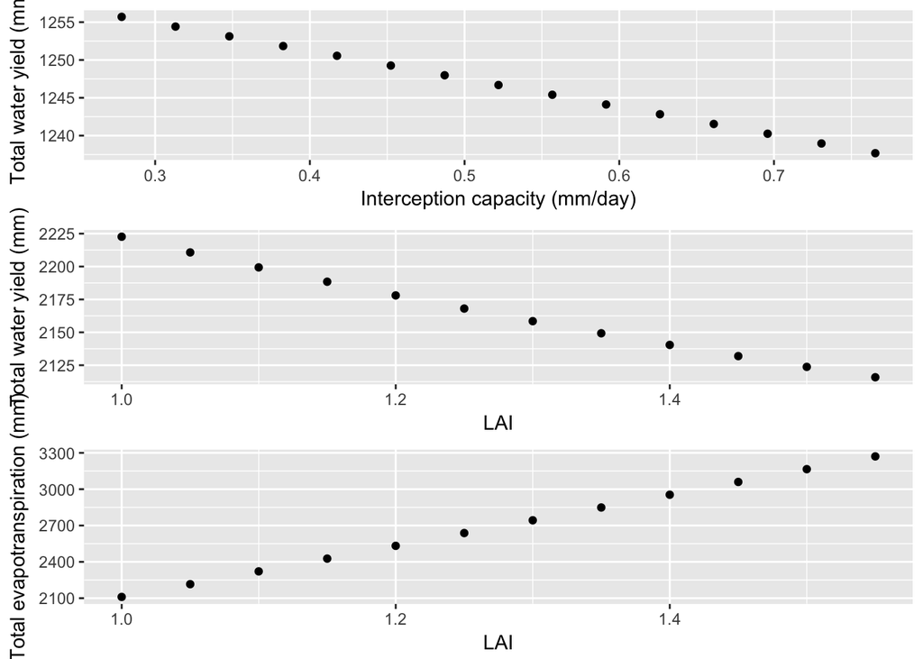

Figure 3. Sesnsitivity analysis for rain interception as fn. of MS and LAI and evapotranspiration as fn. of LAI

Table 1. Summarize of the relative sensitivity of the model to the tested parameters

```
##    Parm      Max      Min      Range
## 1    MS 1255.701 1237.677   18.02356
## 2   LAI 2222.647 2115.839  106.80787
## 3 LAIET 3270.944 2110.286 1160.65745
```

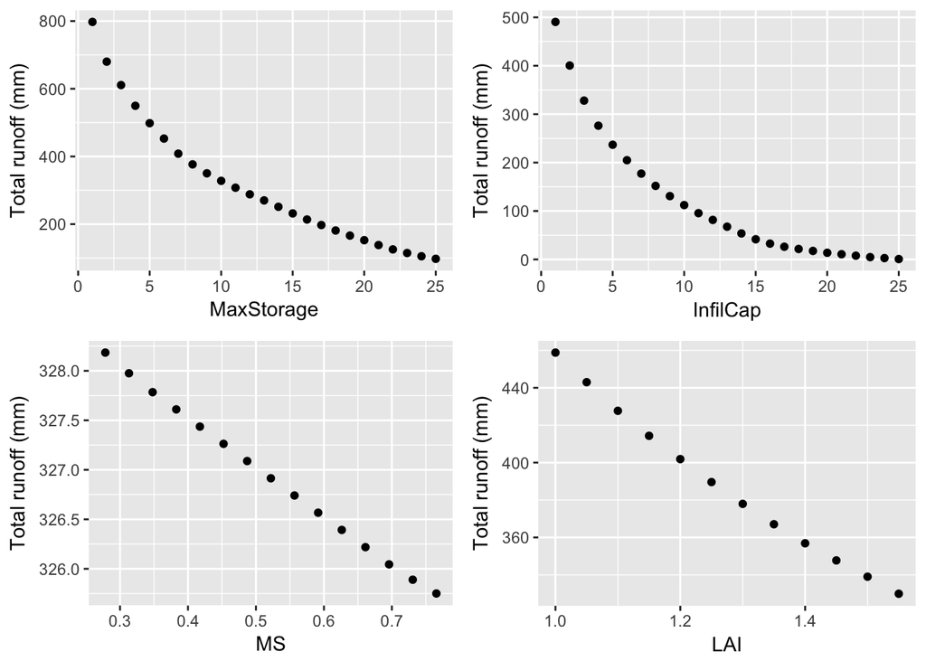

Figure 4. Sesnsitivity analysis for runoff depth as fn. of MaxStorage, InfilaCap, MS and LAI

Table 2. Summarize of the relative sensitivity of the model to the tested parameters

```
##         Parm      Max         Min      Range
## 1 MaxStorage 797.5057  97.6141091 699.891542
## 2  InfilaCap 490.5124   0.7618725 489.750509
## 3         MS 328.1842 325.7505405   2.433638
## 4        LAI 458.8005 329.9032188 128.897286
```

### Set data for GLUE test for the water yield model (different file)

GLUE is a type of calibration analysis, the observed data is taken from the two reservoirs (Willow creek reservoir and North platte). The reservoirs contain baseflow together with runoff unlike the model output. Constant baseflow of (1.4 m3/s (Milhous, 2002) and 15.77 m3/s (Peterson et al., 2015) for Willow ck and North platte respectively) was reduced from each station. Average discharge was converted to runoff depth according to basins area. Average value of this two stations was taken for calibration.

```r
# Set the LAI, InfilCap and MaxStorage values:
LAI = seq(from = 1, to = 1.56, by = 0.05)
InfilCap  = seq(from = 1, to = 10, by = 0.5)
MaxStorage = seq(from = 1, to = 10, by = 0.5)

# Set variables
month_diff = diff(metdata_REP$month)
month_diff[month_diff < 0] = 1
month_index = which(month_diff %in% 1)
month_index_end = c(month_index, length(metdata_REP$month))
month_index_start = c(1,(month_index_end[1:length(month_index_end) - 1]+1))
month_list = metdata_REP$month[month_index_end]
year_list = metdata_REP$Year[month_index_end]

# Set empty matrix to model runs
Runoff_phases = matrix(nrow = length(month_list), ncol = length(LAI)*length(InfilCap)*length(MaxStorage))
it_no = rep(0, times=length(LAI)*length(InfilCap)*length(MaxStorage))
parms = matrix(nrow=length(LAI)*length(InfilCap)*length(MaxStorage), ncol=3)
colnames(parms) = c("LAI", "InfilCap", "MaxStorage")

# Runs for Glue
counter = 1
for (n in 1:length(LAI)){
  for (m in 1:length(InfilCap )){
    for (k in 1:length(MaxStorage)) {

# Call the Water_yield_cold_env fn. to calculate monthly runoff
Runoff_phases[,counter] = Water_yield_cold_env(LAI_living = 1.56,LAI = LAI[n], MS =  0.306, preType = metdata_REP$preType, Tair = metdata_REP$TMAve, P = metdata_REP$P, Smean = 6.6, L0 = 0, c = 0.678, date = metdata_REP$date, lat = 40.3428, Tave = metdata_REP$TMAve, Tmax = metdata_REP$TmMax, Tmin = metdata_REP$TMMin, InfilCap = InfilCap[m], MaxStorage = MaxStorage[k], month = metdata_REP$month, year = metdata_REP$Year)

# Stack parameters sets
it_no[counter] = sprintf("%.2f_%.1f_%.1f", LAI[n], InfilCap[m], MaxStorage[k])
parms[counter, "LAI"] = LAI[n]
parms[counter, "InfilCap"] = InfilCap[m]
parms[counter, "MaxStorage"] = MaxStorage[k]
counter = counter + 1
   }
  }
}

# Create data frame to runoff results:
header = c("day", "month", "year", it_no)
monthly_runoff = data.frame(day = rep(1, length(month_list)), month = month_list, year = year_list, runoff = Runoff_phases)
colnames(monthly_runoff) = header
monthly_runoff$date = as.Date(paste(monthly_runoff$year, monthly_runoff$month, monthly_runoff$day, sep="/"))

# Arrange model runs as original modQ file
nsims_MR = ncol(monthly_runoff)-1
modQ = monthly_runoff[,4:(nsims_MR +1)]
#modQ = modQ[,1:4799]

# Calculate the water year (October - September)
wtr_yr <- function(dates, start_month=9) {
  # Convert dates into POSIXlt
  dates.posix = as.POSIXlt(dates)
  # Year offset
  offset = ifelse(dates.posix$mon >= start_month - 1, 1, 0)
  # Water year
  adj.year = dates.posix$year + 1900 + offset
  # Return the water year
  adj.year
}
 wy = wtr_yr(monthly_runoff$date,start_month=10 )

# Monthly observe runoff values for GLUE
# Convert mean discharge (m^3/s) into runoff depth (mm/day) for Willow creek reservoir (watershed size = 134 square miles) after reduction ofbaseflow (Milhous, 2002) reduce base flow = 1.4 cms
Willow_discharge = metdata_REP$discharg
Willow_discharge[Willow_discharge>1.4] = Willow_discharge[Willow_discharge>1.4] - 1.4
Willow_discharge = (Willow_discharge/3.471e+8)*(60*60*24*1000)
# Convert mean discharge (m^3/s) into runoff depth (mm/day) for North Platte (watershed size = 2840 square miles) reduce base flow 15.77 cms
North_platte_discharge  = North_platte_obs$Discharge
North_platte_discharge[North_platte_discharge > 15.77]  = North_platte_discharge[North_platte_discharge >15.77]- 15.77
North_platte_discharge = (North_platte_discharge/7.3556e+9)*(60*60*24*1000)
Willow_obs = aggregate(Willow_discharge,by=list(metdata_REP$month, metdata_REP$Year), sum)
North_platte_obs = aggregate(North_platte_discharge,by=list(metdata_REP$month,  metdata_REP$Year), sum)
runoff_obs = rowMeans(data.frame(willow = Willow_obs[,3],NP = North_platte_obs[,3] ), na.rm = FALSE, dims = 1)

# Convert date to Julian Day Number (JDN)
 yd = yday(monthly_runoff$date)

 # Create a serial numbers:

 wdy = seq(from = 1, to = length(year_list), by = 1)

 obsQ = data.frame(obs = runoff_obs, date = monthly_runoff$date, year = monthly_runoff$year, month = monthly_runoff$month, day = monthly_runoff$day, wy = wy, yd = yd, wdy = wdy )

 # Arrange parametes file

 parms = data.frame(parms, row = seq(from = 1, to = length(LAI)*length(InfilCap)*length(MaxStorage), by = 1))

 # Save data frame as data file
 setwd("/Users/baravni/Documents/Documents_master/master/R modelling/task1/Writing_Function/")
save(obsQ, file="EcohydrotoolsBAR3/data/obsQ.RData")
save(modQ, file="EcohydrotoolsBAR3/data/modQ.RData")
save(parms, file="EcohydrotoolsBAR3/data/parms.RData")
```

### Water yield calculation for the livinf, red and grey stages

The best parameters that was found in the glue test are in use for the three mortality phases (living, red and grey) (source: Pugh and Gordon, 2013). For this purpose, only InfilCap and Max storage are in use. The LAI values are taken from Pugh and Gordon (2013) to represent the tree condition in each stage.

```r
setwd("/Users/baravni/Documents/Documents_master/master/R modelling/task1/Writing_Function/EcohydrotoolsBAR3/")
data("bestParms")

LAI = c(1.56, 1.35, 1.09)
Runoff_phases = matrix(nrow = length(monthly_runoff$month), ncol = length(LAI))
for (i in 1:length(LAI)){
Runoff_phases[,i] = Water_yield_cold_env(LAI_living = 1.56, LAI = LAI[i], MS = 0.306, preType = metdata_REP$preType, Tair = metdata_REP$TMAve, P = metdata_REP$P, Smean = 6.6, L0 = 0, c = 0.678, date = metdata_REP$date, lat = 40.3428, Tave = metdata_REP$TMAve, Tmax = metdata_REP$TmMax, Tmin = metdata_REP$TMMin, InfilCap = bestParms$InfilCap, MaxStorage = bestParms$MaxStorage, month = metdata_REP$month, year = metdata_REP$Year)
}
```

### Results

The following graph represent the monthly runoff yield from living, red and grey stages. The results are corresponding to the results shown in Pugh and Gordon (2013).

Two graphs are created for December and July for the three stages.

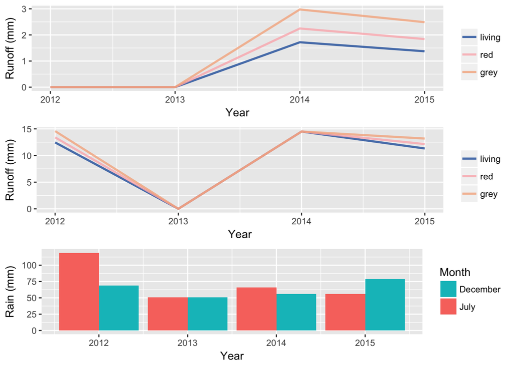

Figure 5. Total runoff and rain (mm) for years 2012-2015 for the three stages: living (blue), red (pink), and grey phase (orange).